# Quick and Dirty Retention Exploratory Data Analysis

Bill Prisbrey

2025-04-25

**PURPOSE:** The purpose of this document is a “quick-and-dirty” or “back-of-the-envelope” exploration. It briefly describes the retention data and superficially calculate and compare principal investigator turnover. It will be used to determine if this project is worth pursuing and guide further data collection and transformation steps.

**OBJECTIVES:**

1. Describe the retention data.
2. Calculate and compare turnover
   1. By colleges **DONE**
   2. By departments **NOT DONE**
   3. By PI clusters **DONE**
   4. By percentiles **TO BE DONE**
3. Determine if there are differences and if they merit continuation of the project.

**NOTES FROM REVIEW MEETING:**

This report was reviewed on 4.30.2025 with the following action item and summary.

Action Items: - Dave to investigate negative and zero values for rehire-to-termination intervals (after Bill sends a list.) - Dave to investigate: - Obtaining information that could describe voluntary and involuntary separation (who was fired vs who quit) - Obtaining birthdates from HR (so we can see if the declining number of PI’s correlates with old age and retirement.) - Bill to investigate: - Proposal submission dates against the hire/rehire/termination intervals - Number of PI’s submitting each year - Tighten up interval definitions and aggregations - Fix x-axis graph labeling - “Tendrils” on the per-week graph of active PI’s - Compare the mean proposal award and see if it is climbing (to verify the declining number of PI’s since COVID.) - Compare counts of hire/rehire/termination dates on the same graphic - Compare PI’s submitting proposals against this view for completion’s sake

**CONCLUSIONS AND NEXT STEPS:**

Several aspects of this report were intriguing:

- The increasing turnover, especially the spike in 2024
- The decline in PI headcount since COVID
- The visual inspection of turnover by cluster showing two clusters moving together and one cluster with a consistently lower turnover

As well, many aspects of this report deserve a better treatment, including attempting to eliminate the guess-work introduced by the hire/rehire dates.

Due to these reasons, it was decided to continue investigating turnover by principal investigators.

# DURATIONS

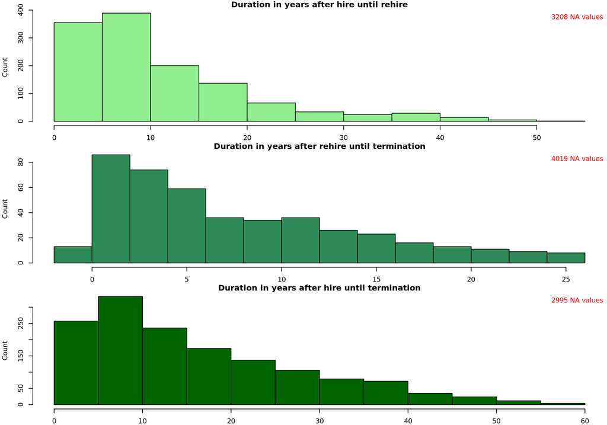

# TERMINATION DATES

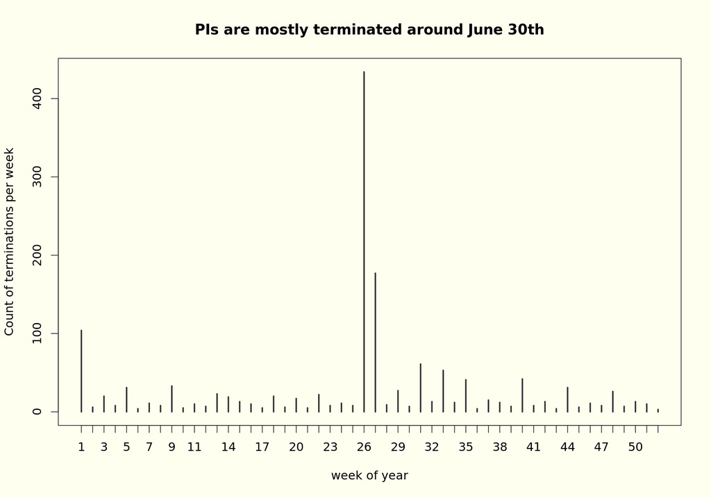

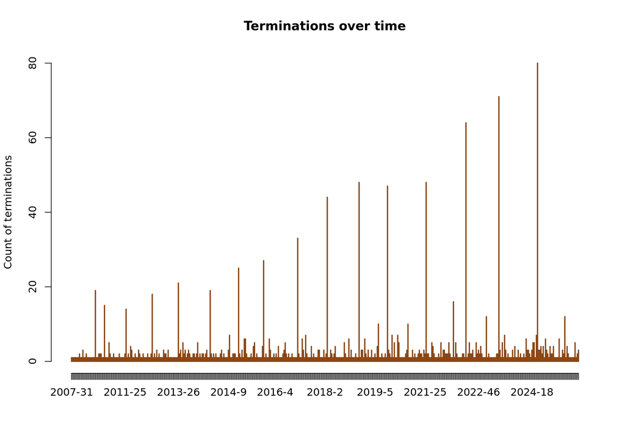

# ACTIVE PRINCIPAL INVESTIGATORS

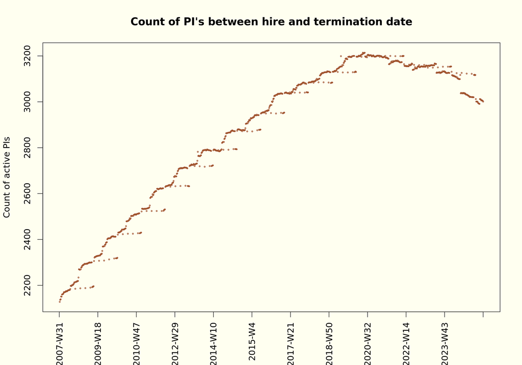

Discussion points:

- Some aspects of this graph appear to be mis-aligned due to how counts per interval were aggregated:
  - Axis labels
  - Points not along the main curve
  - This needs to be investigated
- The general pattern of an increasing count of PI’s that peaked around the year 2020 and declined since needs to be confirmed
- Because the total money requested won has increased, this would mean the average per PI has increased. This could be one double-check.

# TURNOVER

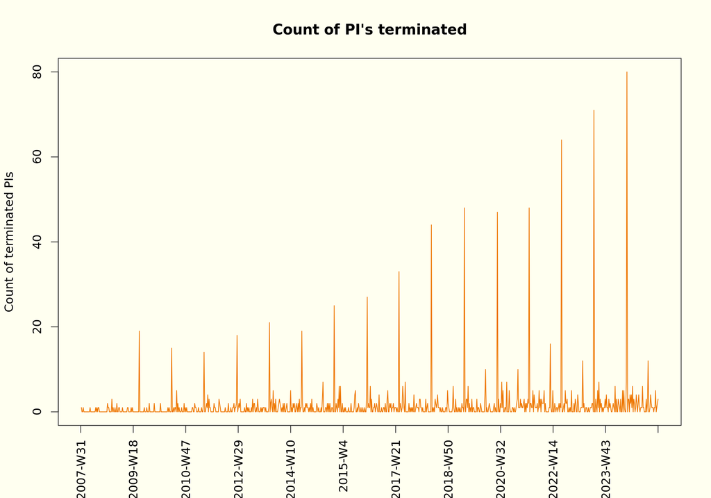

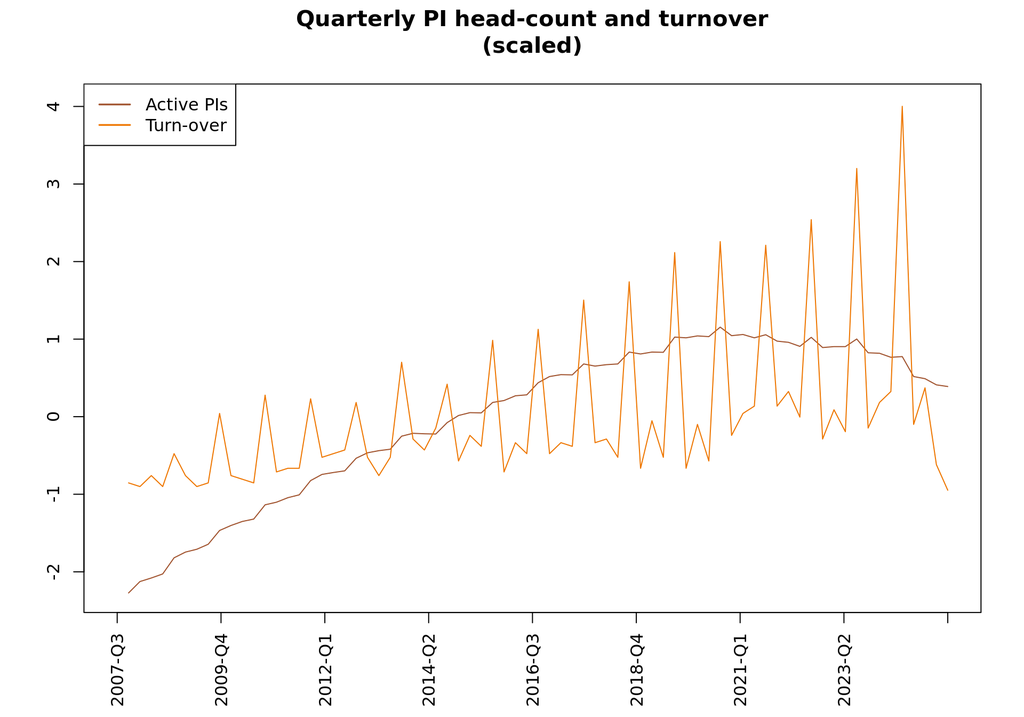

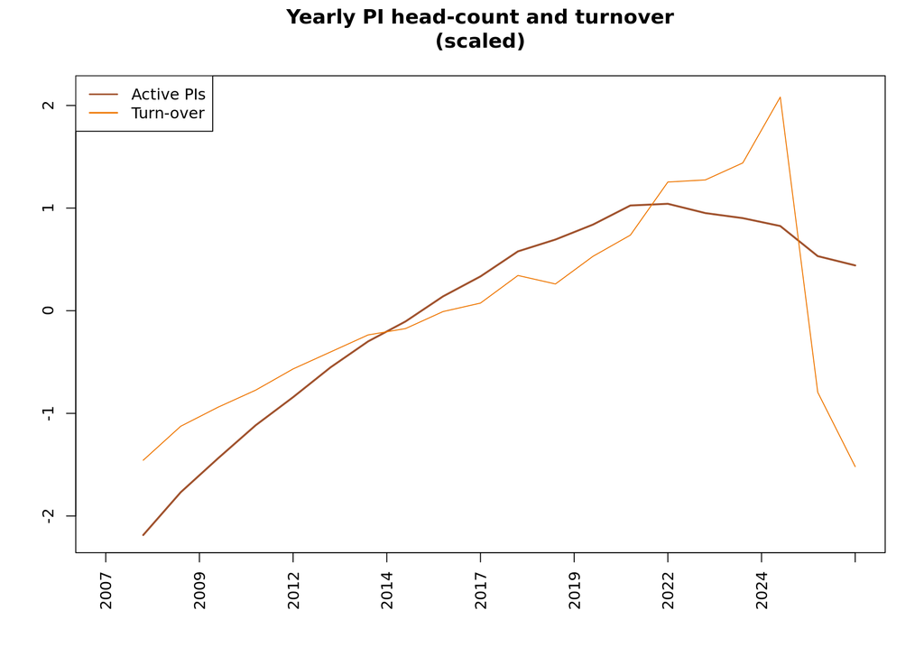

Discussion points:

- Turnover is calculated as the number of exits divided by the average head count of active researchers per period.
- This calculation and graphic needs the same due diligence as noted previously (axis labels shifted and double-check of interval aggregations.)
- The general trend of increasing turnover, spiking last year, is somewhat alarming. It may be worthwhile to compare PI turnover to turnover by all faculty.

# TURNOVER BY COLLEGE

```
##
##  Kruskal-Wallis rank sum test
##
## data:  cT by names(cT)
## Kruskal-Wallis chi-squared = 237, df = 237, p-value = 0.4878
```

[figure not shown]

Discussion points:

- Why do these lines end at different points?
- This is a good graphic for plotly (enables hover-over)
- Kruskal-Wallis test is a pretty rough check  
  # TURNOVER BY COMPLEX CLUSTER

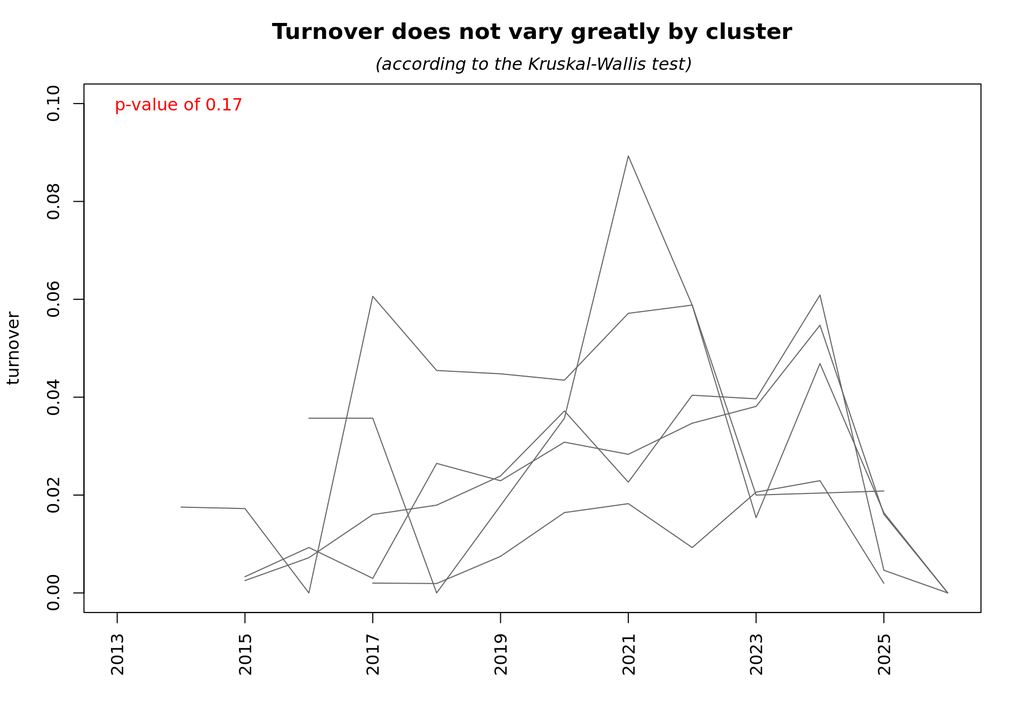

Discussion points:

- Why do these lines end at different points?
- This is a good graphic for plotly (enables hover-over)
- Kruskal-Wallis test is a pretty rough check
  - It isn’t taking the time series into account
- I’d like to add the cluster colors

# DATA DESCRIPTION

Data summary

| Name | retData |
| --- | --- |
| Number of rows | 4463 |
| Number of columns | 18 |
| _______________________ |  |
| Column type frequency: |  |
| character | 9 |
| numeric | 4 |
| POSIXct | 5 |
| ________________________ |  |
| Group variables | None |

**Variable type: character**

| skim_variable | n_missing | complete_rate | min | max | empty | n_unique | whitespace |
| --- | --- | --- | --- | --- | --- | --- | --- |
| PI_EMPLID | 0 | 1 | 1 | 9 | 0 | 4461 | 1 |
| PI_FIRST_NAME | 0 | 1 | 1 | 29 | 0 | 2113 | 0 |
| PI_MIDDLE_NAME | 0 | 1 | 1 | 20 | 0 | 990 | 1541 |
| PI_LAST_NAME | 0 | 1 | 2 | 22 | 0 | 3559 | 0 |
| PI_NAME | 0 | 1 | 5 | 50 | 0 | 4459 | 0 |
| PI_EMAIL_ADDRESS | 0 | 1 | 7 | 39 | 0 | 4460 | 0 |
| PI_PHONE | 0 | 1 | 5 | 16 | 0 | 1749 | 0 |
| PI_INDICATOR | 0 | 1 | 7 | 22 | 0 | 3 | 0 |
| IS_PI | 0 | 1 | 3 | 3 | 0 | 2 | 0 |

**Variable type: numeric**

| skim_variable | n_missing | complete_rate | mean | sd | p0 | p25 | p50 | p75 | p100 | hist |
| --- | --- | --- | --- | --- | --- | --- | --- | --- | --- | --- |
| PI_DIM_KEY | 0 | 1.00 | 2835.92 | 2335.16 | -2.00 | 1129.50 | 2275.00 | 3412.50 | 7913.00 | ▇▇▃▁▃ |
| initial | 3208 | 0.28 | 10.99 | 9.39 | 0.00 | 4.44 | 8.18 | 14.88 | 50.77 | ▇▃▁▁▁ |
| rehire | 4019 | 0.10 | 7.65 | 6.56 | -2.00 | 2.33 | 5.76 | 11.99 | 25.70 | ▇▇▅▂▂ |
| hire | 2995 | 0.33 | 16.28 | 12.21 | 0.22 | 6.54 | 12.83 | 23.92 | 59.47 | ▇▅▂▁▁ |

**Variable type: POSIXct**

| skim_variable | n_missing | complete_rate | min | max | median | n_unique |
| --- | --- | --- | --- | --- | --- | --- |
| PI_LOAD_DATE_TIME | 0 | 1.00 | 2020-05-12 16:02:38 | 2025-04-30 05:00:59 | 2022-04-07 14:09:46 | 437 |
| PI_UPDATE_DATE_TIME | 284 | 0.94 | 2023-06-16 12:37:17 | 2025-04-30 05:00:59 | 2025-01-31 05:01:10 | 182 |
| HIRE_DT | 4 | 1.00 | 1958-09-01 00:00:00 | 2025-02-15 00:00:00 | 2008-06-24 00:00:00 | 1769 |
| REHIRE_DT | 3208 | 0.28 | 1998-07-20 00:00:00 | 2027-02-15 00:00:00 | 2012-08-01 00:00:00 | 611 |
| TERMINATION_DT | 2995 | 0.33 | 2007-08-01 00:00:00 | 2025-04-24 00:00:00 | 2019-11-01 00:00:00 | 626 |